# HW3

財金四 B02703029 許祐瑄

2017/4/24

# 外籍學生議題

```r
library(ggplot2)
library(plotly)
require(stats)

rawdata <- read.csv("/Users/Dan/Desktop/exchange_students.csv",header = TRUE,encoding = "UTF-8", sep=",")

#計算年度長度
yearLength <- length(rawdata$year)
firstyear <- rawdata$year[1]
lastyear <- rawdata$year[yearLength]
n <- lastyear - firstyear +1
alltype <- colnames(rawdata)

#建立新表格
CollegeId <- c(3:13)
newTable <- data.frame()
for (i in 2:n)
{
  year <- as.matrix(rep(rawdata$year[i],length(rawdata[i,CollegeId])))
  people = as.matrix(as.numeric(rawdata[i,CollegeId]))
  type = as.matrix(as.character(alltype[CollegeId]))
  temp = cbind(year, type, people)
  newTable = rbind(newTable, temp)
}

#欄位命名
names(newTable) = c('year', 'College', 'people')
newTable = newTable[with(newTable, order(College)),]
rownames(newTable) <- 1:nrow(newTable)


#依照學院做圖
p <- plot_ly(data = newTable[,1:3], x = ~year,
             y = ~people, color = ~College, main="歷年各院交換生人數") %>%
  add_lines( yaxis = list(range = c(0,10)))
p
```

[interactive chart not shown]

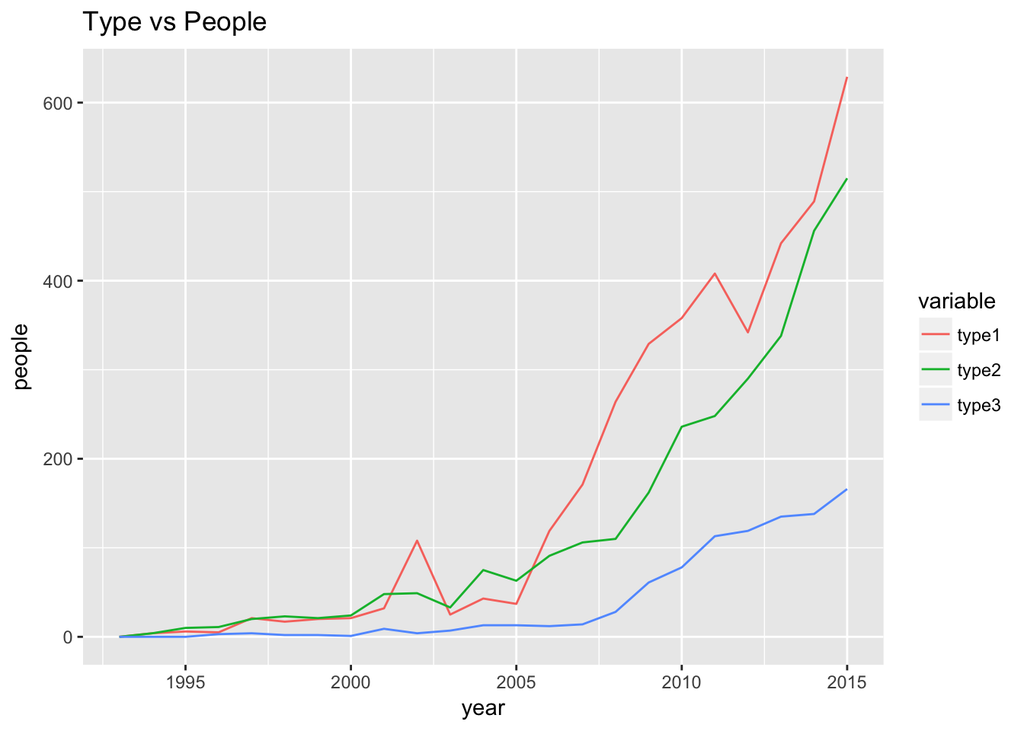

```r
htmlwidgets::saveWidget(p, "index.html")

save(rawdata, newTable, file = "newTable.RData")

#
rawdata2 <- rawdata[,-2]
colnames(rawdata2) <- c("year","2","3","2","1","1","3","1","3","3","2","1")

type1 <- rawdata2[,5] + rawdata2[,6] + rawdata2[,8] +rawdata2[,12]
type2 <- rawdata2[,2] + rawdata2[,4] + rawdata2[,11]
type3 <- rawdata2[,3] + rawdata2[,7] + rawdata2[,9] + rawdata2[,10]
newTable2 <- t(rbind(type1,type2,type3))
newTable2 <- cbind(rawdata[,1], newTable2)
colnames(newTable2) <- c("year","type1","type2","type3")
newTable2 <- as.data.frame(newTable2)

library('reshape2')
plotTable <- melt(newTable2, id.vars="year")
ggplot(data=plotTable, aes(x=year, y=value, group=variable, col=variable)) + geom_line() + ggtitle("Type vs People")+ ylab("people")
```

# 一、二類組出國交換意願較高

從此圖我們可以看到，每個學院在過去幾年來幾乎都呈現上升的趨勢，且管理學院的學生參加交換學程的人數在過去五年來暴增將近兩倍，居各學院之冠，其次則為社會科學院及法律學院。另外我們可以明顯的從圖中看到，以第ㄧ、二類組的學院交換生人數都較三類組學院來得多上許多。

# 後續

未來我們將會針對外籍學生議題做更多的研究，可能包括外籍生人數與英語授課的比例、外籍學生對於台大學生的影響，外籍學生人數的增加是否對於學生出國意願也有正面幫助呢？亦或者探討外籍學生貨交換學生的修課類型等。